# Real-Life Use Cases For Serofoi

2025-07-23

The serofoi package is a tool for estimating the *Force-of-Infection* (FoI) from population-based serosurvey data. In this article, we present three real-life epidemiological scenarios from Latin America to demonstrate the utility of *serofoi* and time-varying models in describing the trajectory of the FoI. For inclusion criteria about serosurvey data and model assumptions, please check [**An Introduction to FoI models**](https://epiverse-trace.github.io/serofoi/articles/foi_models.html).

The scenarios were chosen to showcase the versatility of the serofoi package in different epidemiological contexts:

1. The first scenario presents the rapid spread of chikungunya virus in one of the first states of Brazil to report cases of the disease.
2. The second scenario describes a hidden VEEV emerging transmission in a remote rural area of Eastern Panama.
3. The third scenario involves an endemic downtrend of Chagas disease transmission in a rural endemic area of Colombia.

## Case study 1: Chikungunya (a fast-spreading epidemic scenario)

### The challenge:

Chikungunya is a viral disease that was first described during an outbreak in Tanzania in 1952. For several decades, it was primarily found in Africa and Asia. However, in 2004, the first Chikungunya outbreak outside of these regions occurred on the island of Réunion in the Indian Ocean. Since then, Chikungunya has spread rapidly throughout the world, including to the Americas, Europe, and the Pacific region. In 2013, the first cases of Chikungunya were reported in the Americas, and the virus has since become endemic in several countries in Latin America. The transmission of Chikungunya is primarily through the bites of infected Aedes mosquitoes, with humans serving as the primary amplifying host. The symptoms of Chikungunya include fever, joint pain, headache, muscle pain, and rash, and the disease can range from mild to severe. Although Chikungunya is not typically fatal, it can cause significant morbidity and has the potential to cause large-scale outbreaks, making it an important public health concern. The methodological challenge is how best to estimate the disease burden untangling the endemic and epidemic patterns in several locations around the world. Here *serofoi* can assist with these estimates.

### The dataset:

To gain insights into the transmission dynamics of Chikungunya in the Americas, we used a dataset from a population-based study conducted in Bahia, Brazil in October-December 2015. This study, conducted by Dias et al. (2018), involved household interviews and age-disaggregated serological surveys to measure IgG antibodies against the Chikungunya virus. The survey was conducted immediately after a large Chikungunya epidemic in the area.

### The results:

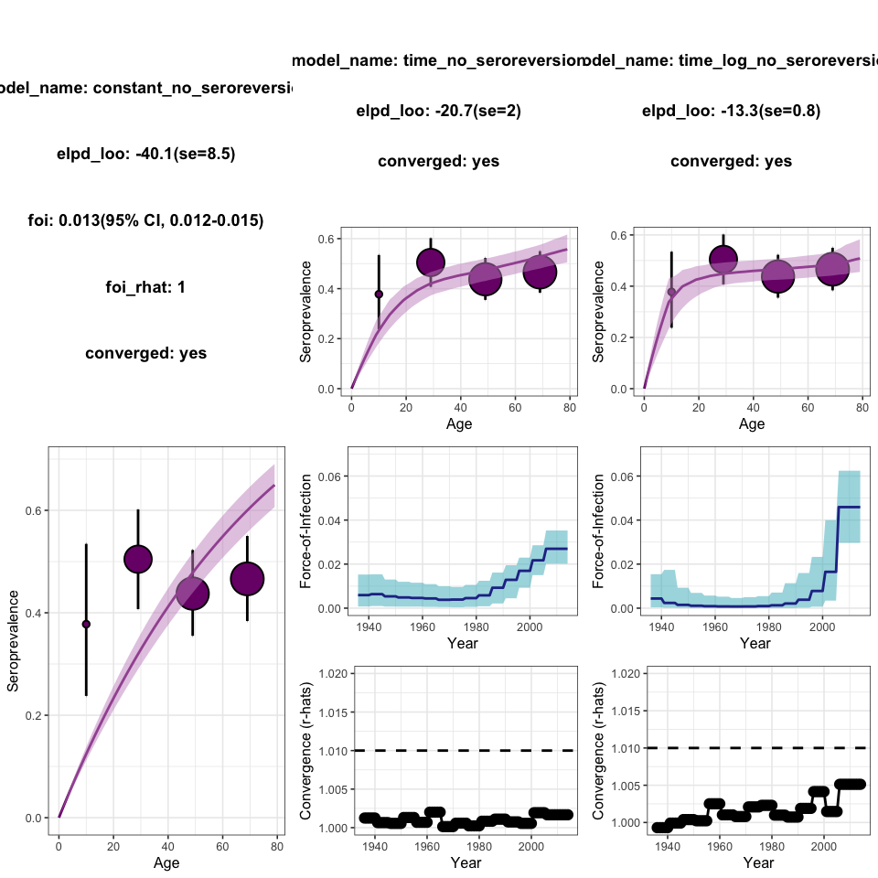

Figure 1. Constant and time-varying serocatalytic models implementation for Chikungunya virus transmission in an urban remote area of Brazil.

```r
# Load and prepare data
data("chik2015")

# Implementation of the models
seromodel_constant <- fit_seromodel(
  serosurvey = chik2015,
  model_type = "constant",
  iter = 1000
)

foi_index <- get_foi_index(chik2015, group_size = 5, model_type = "time")
seromodel_time <- fit_seromodel(
  serosurvey = chik2015,
  model_type = "time",
  foi_prior = sf_normal(0, 0.01),
  foi_index = foi_index,
  iter = 2500
)

foi_index <- get_foi_index(chik2015, group_size = 5, model_type = "time")
seromodel_log_time <- fit_seromodel(
  serosurvey = chik2015,
  model_type = "time",
  foi_prior = sf_normal(0, 0.01),
  is_log_foi = TRUE,
  foi_index = foi_index,
  iter = 2000
)

# Visualisation of the results
plot_constant <- plot_seromodel(
  seromodel = seromodel_constant,
  serosurvey = chik2015,
  foi_max = 0.07,
  size_text = 6
)
plot_time <- plot_seromodel(
  seromodel = seromodel_time,
  serosurvey = chik2015,
  foi_max = 0.07,
  size_text = 6
)
plot_log_time <- plot_seromodel(
  seromodel = seromodel_log_time,
  serosurvey = chik2015,
  foi_max = 0.07,
  size_text = 6
)

cowplot::plot_grid(plot_constant, plot_time, plot_log_time, ncol = 3)
```

## Case study 2. Hidden Alphaviruses epidemics in Panama

### The challenge:

emerging alphaviruses, including *Venezuelan Equine Encephalitis Virus (VEEV)*, are RNA viruses that can cause disease in both humans and animals. They are primarily transmitted by mosquitoes and have a complex transmission cycle that involves human and non-human hosts, including birds and mammals. Alphaviruses can cause significant morbidity and mortality. Hidden epidemics and endemic transmission of alphaviruses have been occurring in small and remote communities of Eastern Panama for decades without major notice [@carrera2020]. The main concern with alphaviruses is their potential to spill over into human populations and reach highly populated cities and urban areas where humans are more susceptible. The Darien province in Eastern Panama, bordering the north of Colombia to the south and the Pacific Ocean, is home to several indigenous communities who live in traditional and remote villages. Notably, the area is also a critical crossing point for illegal immigration from Africa and South America to the north of the Americas. Estimating the temporal trends of the incidence of alphaviruses in this region is a methodological challenge but critical to inform control strategies. *serofoi* can assist with these estimations.

### The dataset:

From [@carrera2020], we use a dataset measuring IgG antibodies against *VEEV* in a rural village in Panamá in 2012. *VEEV* is primarily transmitted by mosquitoes and can cause disease in horses and humans. This dataset, `veev2012` is included in *serofoi*.

### The result:

*serofoi* was used to compare three potential scenarios of *VEEV* transmission: *constant endemic*, *epidemic slow*, and *epidemic fast*. The results showed a significant increase in the estimated FoI in the region, indicating a rise in *VEEV* transmission. The study found that there was much higher statistical support for a time-varying rather than a constant scenario based on higher elpd and lower se values of the two time-varying models compared to the constant one (Figure 2). The results also suggest slightly (yet relevant) better support for model 3 (`log-time`), compared to model 2 (`time`), suggesting a recent increase in transmission in the study area.

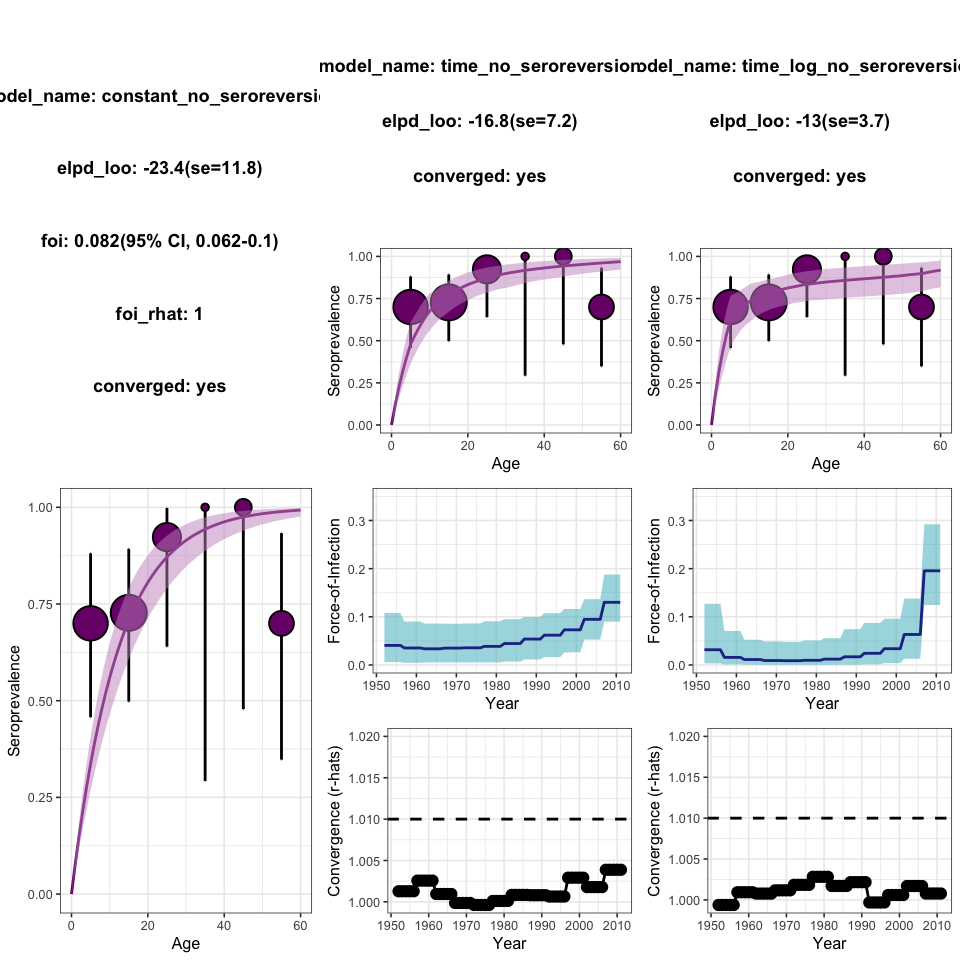

Figure 2. Constant and time-varying serocatalytic models implementation for VEEV transmission in a rural remote area of Panama.

```r
# Load and prepare data
data("veev2012")

# Implementation of the models
seromodel_constant <- fit_seromodel(
  serosurvey = veev2012,
  model_type = "constant",
  iter = 1000
)

foi_index <- get_foi_index(veev2012, group_size = 5, model_type = "time")
seromodel_time <- fit_seromodel(
  serosurvey = veev2012,
  model_type = "time",
  foi_prior = sf_normal(0, 0.1),
  foi_index = foi_index,
  iter = 2000
)

foi_index <- get_foi_index(veev2012, group_size = 5, model_type = "time")
seromodel_log_time <- fit_seromodel(
  serosurvey = veev2012,
  model_type = "time",
  foi_prior = sf_normal(0, 0.1),
  is_log_foi = TRUE,
  foi_index = foi_index,
  iter = 2000
)

# Visualisation of the results
plot_constant <- plot_seromodel(
  seromodel = seromodel_constant,
  serosurvey = veev2012,
  foi_max = 0.35,
  size_text = 6
)
plot_time <- plot_seromodel(
  seromodel = seromodel_time,
  serosurvey = veev2012,
  foi_max = 0.35,
  size_text = 6
)
plot_log_time <- plot_seromodel(
  seromodel = seromodel_log_time,
  serosurvey = veev2012,
  foi_max = 0.35,
  size_text = 6
)

cowplot::plot_grid(plot_constant, plot_time, plot_log_time, ncol = 3)
```

## Case study 3. Chagas disease (endemic disease)

### The challenge:

Chagas disease is a parasitic infection caused by the protozoan *Trypanosoma cruzi*. It is only endemic to Latin America, where it is transmitted to humans through the bite of infected triatomine bugs, which have been present in the Americas for thousands of years. Triatomine bugs have established domiciliary habits, living inside houses and biting humans. Insecticide spraying is the primary control strategy for Chagas disease, as it effectively reduces the population of triatomine bugs, the main vector of the disease, in domestic environments. According to [@cucunubá2017], interventions for Chagas disease control have been ongoing in Colombia since the 1980s, with a heterogeneous impact depending on the type of setting, environment, and population. There is a **methodological challenge** in how best to estimate the historical effectiveness of these control strategies across endemic areas. Here *serofoi* can assist with these estimations.

### The dataset

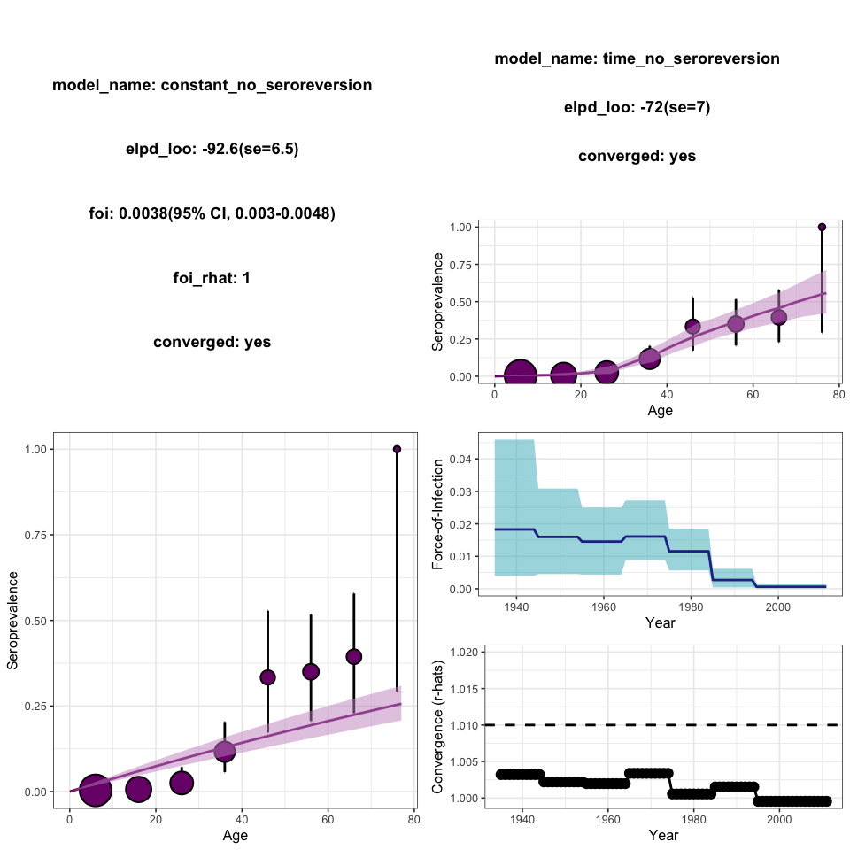

Figure 3. Endemic models implementation for Trypanosoma cruzi in a rural area of Colombia.

```r
# Load and prepare data
data("chagas2012")

# Implementation of the models
seromodel_constant <- fit_seromodel(
  serosurvey = chagas2012,
  model_type = "constant",
  iter = 800
)

foi_index <- get_foi_index(chagas2012, group_size = 10, model_type = "time")
seromodel_time <- fit_seromodel(
  serosurvey = chagas2012,
  model_type = "time",
  foi_index = foi_index,
  iter = 1500
)

# Visualisation of the results
plot_constant <- plot_seromodel(
  seromodel = seromodel_constant,
  serosurvey = chagas2012,
  bin_serosurvey = TRUE,
  bin_step = 10,
  size_text = 6
)
plot_time <- plot_seromodel(
  seromodel = seromodel_time,
  serosurvey = chagas2012,
  bin_serosurvey = TRUE,
  bin_step = 10,
  size_text = 6
)
cowplot::plot_grid(plot_constant, plot_time, ncol = 2)
```